# Machine-Learning-by-example-notebook

## Machine Learning By Example Tasks

### Task 1-2:

```python
import sys

assert sys.version_info >= (3,7)
```

```python
import matplotlib.pyplot as plt

plt.rc('font', size=14) #general font size
plt.rc('axes', labelsize=14, titlesize=14) #font size for the titles of x and y axes
plt.rc('legend', fontsize=14) # font size for legends
plt.rc('xtick', labelsize=10) # the font size of labels for intervals marked on the x axis
plt.rc('ytick', labelsize=10) # the font size of labels for intervals marked on the y axis
```

```python
from pathlib import Path

IMAGES_PATH = Path() / "images" / "classification"
IMAGES_PATH.mkdir(parents=True, exist_ok=True)

def save_fig(fig_id, tight_layout=True, fig_extension="png", resolution=300):
    path = IMAGES_PATH / f"{fig_id}.{fig_extension}"
    if tight_layout:
        plt.tight_layout()
    plt.savefig(path, format=fig_extension, dpi=resolution)
```

## Task 1-4

#### How framing the problem affects data selection

Firstly, the articles show that one of the important steps with framing our problem is so that we have clarity in what our objective is. This in turn helps us determine what the role of our model will be clearly and allows us to better select the right machine learning algorithm for the task. The readings suggest that a well defined task also helps with guiding the collection and preparation of data, if we do not define our problem and objectives, how can we collect data that has meaning. Also, understanding the task helps identify potential ethical considerations associated with the use of machine learning as demonstrated in the AI facial recognition article.

#### Selecting Algorithm

Regression would be better suited for predicting median house pricing because the output is quantities that are based on the input of the model.

Classification would be better suited for handwritten digit recognition because of multi-class classification which would be involved in the model.

## Task 2-1

#### Downloading example tabular data

```python
from pathlib import Path
import pandas as pd
import tarfile
import urllib.request

def load_housing_data():
    tarball_path = Path("datasets/housing.tgz")
    if not tarball_path.is_file():
        Path("datasets").mkdir(parents=True, exist_ok=True)
        url = "https://github.com/ageron/data/raw/main/housing.tgz"
        urllib.request.urlretrieve(url, tarball_path)
        with tarfile.open(tarball_path) as housing_tarball:
            housing_tarball.extractall(path="datasets")
    return pd.read_csv(Path("datasets/housing/housing.csv"))

housing = load_housing_data()
```

```python
housing.info()
```

```
<class 'pandas.core.frame.DataFrame'>
RangeIndex: 20640 entries, 0 to 20639
Data columns (total 10 columns):
 #   Column              Non-Null Count  Dtype
---  ------              --------------  -----
 0   longitude           20640 non-null  float64
 1   latitude            20640 non-null  float64
 2   housing_median_age  20640 non-null  float64
 3   total_rooms         20640 non-null  float64
 4   total_bedrooms      20433 non-null  float64
 5   population          20640 non-null  float64
 6   households          20640 non-null  float64
 7   median_income       20640 non-null  float64
 8   median_house_value  20640 non-null  float64
 9   ocean_proximity     20640 non-null  object
dtypes: float64(9), object(1)
memory usage: 1.6+ MB
```

There are 10 attributes and one of them ocean_proximity is not numerical

```python
housing["ocean_proximity"].value_counts()
```

```
ocean_proximity
<1H OCEAN     9136
INLAND        6551
NEAR OCEAN    2658
NEAR BAY      2290
ISLAND           5
Name: count, dtype: int64
```

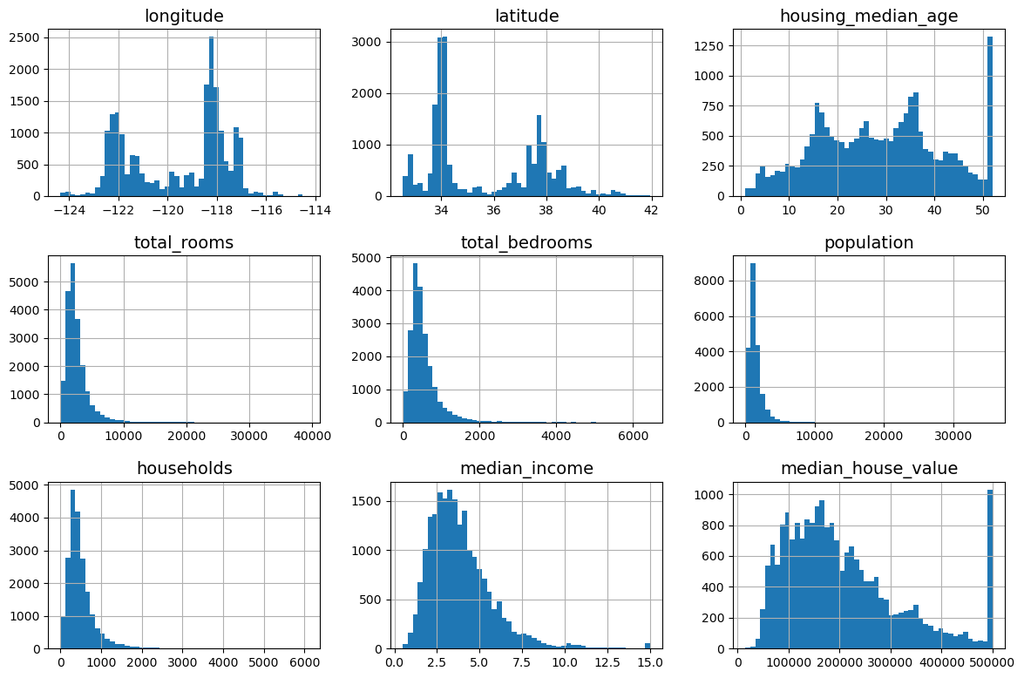

```python
housing.hist(bins=50, figsize=(12, 8))
save_fig("attribute_histogram_plots")
plt.show()
```

```python
housing.describe()
```

|  | longitude | latitude | housing_median_age | total_rooms | total_bedrooms | population | households | median_income | median_house_value |
| --- | --- | --- | --- | --- | --- | --- | --- | --- | --- |
| count | 20640.000000 | 20640.000000 | 20640.000000 | 20640.000000 | 20433.000000 | 20640.000000 | 20640.000000 | 20640.000000 | 20640.000000 |
| mean | -119.569704 | 35.631861 | 28.639486 | 2635.763081 | 537.870553 | 1425.476744 | 499.539680 | 3.870671 | 206855.816909 |
| std | 2.003532 | 2.135952 | 12.585558 | 2181.615252 | 421.385070 | 1132.462122 | 382.329753 | 1.899822 | 115395.615874 |
| min | -124.350000 | 32.540000 | 1.000000 | 2.000000 | 1.000000 | 3.000000 | 1.000000 | 0.499900 | 14999.000000 |
| 25% | -121.800000 | 33.930000 | 18.000000 | 1447.750000 | 296.000000 | 787.000000 | 280.000000 | 2.563400 | 119600.000000 |
| 50% | -118.490000 | 34.260000 | 29.000000 | 2127.000000 | 435.000000 | 1166.000000 | 409.000000 | 3.534800 | 179700.000000 |
| 75% | -118.010000 | 37.710000 | 37.000000 | 3148.000000 | 647.000000 | 1725.000000 | 605.000000 | 4.743250 | 264725.000000 |
| max | -114.310000 | 41.950000 | 52.000000 | 39320.000000 | 6445.000000 | 35682.000000 | 6082.000000 | 15.000100 | 500001.000000 |

## Task 2-2

```python
from sklearn.datasets import fetch_openml
import pandas as pd

mnist = fetch_openml('mnist_784', as_frame=False, parser='auto')
```

```python
print (mnist.DESCR)
```

```
**Author**: Yann LeCun, Corinna Cortes, Christopher J.C. Burges
**Source**: [MNIST Website](http://yann.lecun.com/exdb/mnist/) - Date unknown
**Please cite**:

The MNIST database of handwritten digits with 784 features, raw data available at: http://yann.lecun.com/exdb/mnist/. It can be split in a training set of the first 60,000 examples, and a test set of 10,000 examples

It is a subset of a larger set available from NIST. The digits have been size-normalized and centered in a fixed-size image. It is a good database for people who want to try learning techniques and pattern recognition methods on real-world data while spending minimal efforts on preprocessing and for…

With some classification methods (particularly template-based methods, such as SVM and K-nearest neighbors), the error rate improves when the digits are centered by bounding box rather than center of mass. If you do this kind of pre-processing, you should report it in your publications. The MNIST da…

The MNIST training set is composed of 30,000 patterns from SD-3 and 30,000 patterns from SD-1. Our test set was composed of 5,000 patterns from SD-3 and 5,000 patterns from SD-1. The 60,000 pattern training set contained examples from approximately 250 writers. We made sure that the sets of writers …

Downloaded from openml.org.
```

## Task 2-3

*Mark Down cell for critique*

1. Data transformation was done by transforming the originial NIST dataset of black and white images by size-normalising the digits and using anti-aliasing for grey levels
2. They selected subsets from NIST, with SD-3 designated as the training set and SD-1 as the test set by considering factors like cleanliness and recognisability
3. The MNIST training set was formed by combining 30,000 patterns from SD-3 and 30,00 patterns from SD-1, the test set comprised 5000 patterns from each
4. The decisions made were justified as they aimed to address issues related to data quality, standardisation and independence of training and test sets. These are useful for a reliable evaluation of machine learning models.

## Task 2-4

```python
mnist.keys()
```

```
dict_keys(['data', 'target', 'frame', 'categories', 'feature_names', 'target_names', 'DESCR', 'details', 'url'])
```

```python
images = mnist.data
categories = mnist.target

print("Shape of Images:", images.shape)

print("Categories", categories.tolist())
```

```
Shape of Images: (70000, 784)
Categories ['5', '0', '4', '1', '9', '2', '1', '3', '1', '4', '3', '5', '3', '6', '1', '7', '2', '8', '6', '9', '4', '0', '9', '1', '1', '2', '4', '3', '2', '7', '3', '8', '6', '9', '0', '5', '6', '0', '7', '6', '1', '8', '7', '9', '3', '9', '8', '5', '9', '3', '3', '0', '7', '4', '9', '8', '0', '9'…
```

```python
import matplotlib.pyplot as plt

def plot_digit(image_data):
    image = image_data.reshape(28, 28)
    plt.imshow(image, cmap="binary")
    plt.axis("off")
```

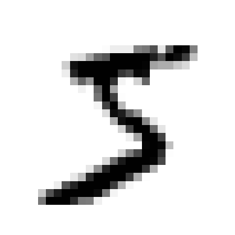

```python
some_digit = mnist.data[0]
plot_digit(some_digit)
plt.show()
```

## Task 3: Setting aside test data

```python
from sklearn.model_selection import train_test_split

tratio = 0.2

train_set, test_set = train_test_split(housing, test_size=tratio, random_state=42)
```

```python
import numpy as np

sample_size = 1000
ratio_female = 0.511

np.random.seed(42)

samples = (np.random.rand(100_000, sample_size) < ratio_female).sum(axis=1)
((samples < 485) | (samples > 535)).mean()
```

```
0.1071
```

```python
import numpy as np
import pandas as pd

housing["income_cat"] = pd.cut(housing["median_income"],
                               bins=[0., 1.5, 3.0, 4.5, 6., np.inf],
                               labels=[1, 2, 3, 4, 5])
```

```python
from sklearn.model_selection import train_test_split

tratio = 0.2

strat_train_set, strat_test_set = train_test_split(housing, test_size=tratio, stratify=housing["income_cat"], random_state=42)
```

```python
strat_test_set["income_cat"].value_counts() / len(strat_test_set)
```

```
income_cat
3    0.350533
2    0.318798
4    0.176357
5    0.114341
1    0.039971
Name: count, dtype: float64
```

### Why is a stratified sample based on median income reasonable?

*Markdown cell*

1. Stratified sampling based on median income ensures that each stratum is adequately represented in the sample, helping to capture the diversity of the population in terms of economic diversity.
2. Stratified sampling can lead to a more precise estimation each income group. Particularly important for anaylsing subpopulations ith specific income characteristics.
3. Provides proportional representation of each income stratum which ensures fairness in the presentation of different socioeconomic groups
4. The results of a stratified sample are more likely to generalise well into the overall population.

### Task 3.2: Setting aside test set for image data

```python
X_train = mnist.data[:60000]
y_train = mnist.target[:60000]

X_test = mnist.data[60000:]
y_test = mnist.target[60000:]
```

## Task 4

### Step 1 Checking correlations: training set

```python
housing = strat_train_set.copy()
```

```python
corr_matrix = housing.corr(numeric_only=True)
corr_matrix["median_house_value"].sort_values(ascending=False)
```

```
median_house_value    1.000000
median_income         0.688380
total_rooms           0.137455
housing_median_age    0.102175
households            0.071426
total_bedrooms        0.054635
population           -0.020153
longitude            -0.050859
latitude             -0.139584
Name: median_house_value, dtype: float64
```

### Step 2: Visualise Correlations

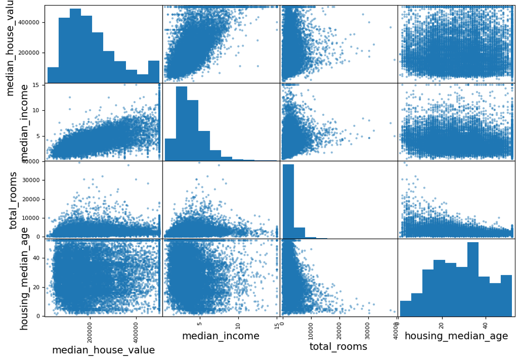

```python
from pandas.plotting import scatter_matrix

features = ["median_house_value", "median_income", "total_rooms",
              "housing_median_age"]
scatter_matrix(housing[features], figsize=(12, 8))


plt.show()
```

### Step 3: Separate the target labels from data

```python
housing = strat_train_set.drop("median_house_value", axis=1)
housing_labels = strat_train_set["median_house_value"].copy()
```

### Step 4: Look for missing values in data

```python
housing.info()
```

```
<class 'pandas.core.frame.DataFrame'>
Index: 16512 entries, 13096 to 19888
Data columns (total 10 columns):
 #   Column              Non-Null Count  Dtype
---  ------              --------------  -----
 0   longitude           16512 non-null  float64
 1   latitude            16512 non-null  float64
 2   housing_median_age  16512 non-null  float64
 3   total_rooms         16512 non-null  float64
 4   total_bedrooms      16344 non-null  float64
 5   population          16512 non-null  float64
 6   households          16512 non-null  float64
 7   median_income       16512 non-null  float64
 8   ocean_proximity     16512 non-null  object
 9   income_cat          16512 non-null  category
dtypes: category(1), float64(8), object(1)
memory usage: 1.3+ MB
```

```python
missing_values = housing.isnull().sum()
```

```python
missing_total_bedrooms = missing_values['total_bedrooms']

print("Number of missing values for 'total_bedrooms':", missing_total_bedrooms)
```

```
Number of missing values for 'total_bedrooms': 168
```

### Step 5: Handling missing Values

```python
from sklearn.impute import SimpleImputer

imputer = SimpleImputer(strategy="median")

housing_num = housing.select_dtypes(include=[np.number])

imputer.fit(housing_num)

housing_num[:] = imputer.transform(housing_num)
```

#### Comments

It seems like using SimpleImputer to fill in the missing values with the median is the most straightforward way to deal with the problem but it seems like potentially you are oversimplifying your data by filling missing values with the median.

### Step 6: Scaling features

```python
housing_num.describe()
```

|  | longitude | latitude | housing_median_age | total_rooms | total_bedrooms | population | households | median_income |
| --- | --- | --- | --- | --- | --- | --- | --- | --- |
| count | 16512.000000 | 16512.000000 | 16512.000000 | 16512.000000 | 16512.000000 | 16512.000000 | 16512.000000 | 16512.000000 |
| mean | -119.573125 | 35.637746 | 28.577156 | 2639.402798 | 537.881298 | 1425.513929 | 499.990189 | 3.870428 |
| std | 2.000624 | 2.133294 | 12.585738 | 2185.287466 | 421.831667 | 1094.795467 | 382.865787 | 1.891936 |
| min | -124.350000 | 32.550000 | 1.000000 | 2.000000 | 1.000000 | 3.000000 | 1.000000 | 0.499900 |
| 25% | -121.800000 | 33.930000 | 18.000000 | 1447.000000 | 297.000000 | 787.000000 | 279.000000 | 2.562500 |
| 50% | -118.510000 | 34.260000 | 29.000000 | 2125.000000 | 434.000000 | 1167.000000 | 408.000000 | 3.538500 |
| 75% | -118.010000 | 37.720000 | 37.000000 | 3154.000000 | 642.000000 | 1726.000000 | 603.000000 | 4.750000 |
| max | -114.490000 | 41.950000 | 52.000000 | 39320.000000 | 6210.000000 | 16305.000000 | 5358.000000 | 15.000100 |

```python
from sklearn.preprocessing import StandardScaler

std_scaler = StandardScaler()
housing_num_std_scaled = std_scaler.fit_transform(housing_num)
```

```python
housing_num[:]=std_scaler.fit_transform(housing_num)
```

### Step 7 Train a linear regression model

```python
target_scaler = StandardScaler()
scaled_labels = target_scaler.fit_transform(housing_labels.to_frame())
```

```python
from sklearn.linear_model import LinearRegression #get the library from sklearn.linear model

model = LinearRegression() #get an instance of the untrained model
model.fit(housing_num, scaled_labels)
model.fit(housing[["median_income"]], scaled_labels)
some_new_data = housing[["median_income"]].iloc[:5]

scaled_predictions = model.predict(some_new_data)
predictions = target_scaler.inverse_transform(scaled_predictions)
```

```python
some_new_data = housing_num.iloc[:5]
some_new_data = housing[["median_income"]].iloc[:5]

scaled_predictions = model.predict(some_new_data)
predictions = target_scaler.inverse_transform(scaled_predictions)
```

```python
print(predictions, housing_labels.iloc[:5])
```

```
[[131997.15275877]
 [299359.35844434]
 [146023.37185694]
 [138840.33653057]
 [192016.61557639]] 13096    458300.0
14973    483800.0
3785     101700.0
14689     96100.0
20507    361800.0
Name: median_house_value, dtype: float64
```

### Step 8 Cross Validation

```python
from sklearn.model_selection import cross_val_score

rmses = -cross_val_score(model, housing_num, scaled_labels,
                              scoring="neg_root_mean_squared_error", cv=10)
```

```python
pd.Series(rmses).describe()
```

```
count    10.000000
mean      0.600606
std       0.007835
min       0.591452
25%       0.594204
50%       0.598207
75%       0.608375
max       0.611381
dtype: float64
```

## Task 4: Hand written digit classification

### Step 1 Getting the data

```python
import tensorflow as tf

mnist = tf.keras.datasets.mnist.load_data()
```

```
Downloading data from https://storage.googleapis.com/tensorflow/tf-keras-datasets/mnist.npz
```

### Reviewing what the data looks like

```python
print(type(mnist))
```

```
<class 'tuple'>
```

### Step 3 how to get the data

```python
(X_train_full, y_train_full), (X_test, y_test) = mnist
```

### Step 4 Scaling the pixel values (the features)

```python
X_train_full = X_train_full / 255.
X_test = X_test / 255.
```

### Step 5 Split the training data into training and validation data

```python
X_train, X_valid = X_train_full[:-5000], X_train_full[-5000:]
y_train, y_valid = y_train_full[:-5000], y_train_full[-5000:]
```

### increasing the dimension to include color channels

```python
import numpy as np

X_train = X_train[..., np.newaxis]
X_valid = X_valid[..., np.newaxis]
X_test = X_test[..., np.newaxis]
```

### Step 6 building the neural network and fit it to the data

```python
tf.keras.backend.clear_session()

tf.random.set_seed(42)
np.random.seed(42)


model = tf.keras.Sequential([
    tf.keras.layers.Conv2D(32, kernel_size=3, padding="same", activation="relu", kernel_initializer="he_normal"),
    tf.keras.layers.Conv2D(64, kernel_size=3, padding="same", activation="relu", kernel_initializer="he_normal"),
    tf.keras.layers.MaxPool2D(),
    tf.keras.layers.Flatten(),
    tf.keras.layers.Dropout(0.25),
    tf.keras.layers.Dense(128, activation="relu", kernel_initializer="he_normal"),
    tf.keras.layers.Dropout(0.5),
    tf.keras.layers.Dense(10, activation="softmax")
])
model.compile(loss="sparse_categorical_crossentropy", optimizer="nadam",
              metrics=["accuracy"])

model.fit(X_train, y_train, epochs=10, validation_data=(X_valid, y_valid))
```

```
2023-12-15 05:54:24.264880: W tensorflow/tsl/platform/profile_utils/cpu_utils.cc:128] Failed to get CPU frequency: 0 Hz
```

```
<keras.callbacks.History at 0x17cdc9e50>
```

```python
model.summary()
```

```
Model: "sequential"
_________________________________________________________________
 Layer (type)                Output Shape              Param #
=================================================================
 conv2d (Conv2D)             (None, 28, 28, 32)        320

 conv2d_1 (Conv2D)           (None, 28, 28, 64)        18496

 max_pooling2d (MaxPooling2D  (None, 14, 14, 64)       0
 )

 flatten (Flatten)           (None, 12544)             0

 dropout (Dropout)           (None, 12544)             0

 dense (Dense)               (None, 128)               1605760

 dropout_1 (Dropout)         (None, 128)               0

 dense_1 (Dense)             (None, 10)                1290

=================================================================
Total params: 1,625,866
Trainable params: 1,625,866
Non-trainable params: 0
_________________________________________________________________
```

### Step 7 Training and evaluating the model

```python
model.evaluate(X_test, y_test)
```

```
[0.030646217986941338, 0.9927999973297119]
```

### data from scikitlearn

```python
from sklearn.datasets import fetch_openml
import pandas as pd

mnist = fetch_openml('mnist_784', as_frame=False, parser='auto')


images = mnist.data
categories = mnist.target
```

```python
from sklearn.linear_model import SGDClassifier
from sklearn.model_selection import cross_val_score

sgd_clf = SGDClassifier(random_state=42)



accuracy = cross_val_score(sgd_clf, images, categories, cv=10)

print(accuracy)
```

```
[0.872      0.86071429 0.87614286 0.86442857 0.84942857 0.86271429
 0.87914286 0.858      0.892      0.889     ]
```